# QTM302W Methods Section

Isabella Adeola, Christina Dai, Hank Standaert

2025-11-06

## R Markdown

```r
library(dplyr)
library(tidyverse)
```

```r
library(ggplot2)
library(kableExtra)
library(gridExtra)
ciri_data <- read_csv("data/dataverse_files/CIRI Data 1981_2011 2014.04.14.csv")
#Removing unnecessary variables from data set
df <- ciri_data %>%
  select(-c(DISAP,
            UNCTRY,
            CIRI,
            KILL,
            POLPRIS,
            COW,
            TORT,
            UNSUBREG,
            POLITY,
            OLD_EMPINX,
            NEW_EMPINX,
            ASSN,
            FORMOV,
            DOMMOV,
            OLD_MOVE,
            SPEECH,
            ELECSD,
            OLD_RELFRE,
            NEW_RELFRE,
            WORKER,
            WOSOC,
            INJUD))
```

```r
# Checking for number of NA's in each variable and deleting rows with NA's
print(colSums(is.na(df)))
```

```
##    CTRY    YEAR   UNREG PHYSINT   WECON   WOPOL
##       0       0       0    1347    1220    1220
```

```r
df_full <- na.omit(df)

# Checking for duplicates within variables and duplicate rows
print(sum(duplicated(df_full)))
```

```
## [1] 0
```

```r
df_no_dups <- distinct(df_full)
```

```r
# Making missing code, periods of interregnum, and occupation NAs
df_no_dups[df_no_dups == -999] <- NA
df_no_dups[df_no_dups == -77]  <- NA
df_no_dups[df_no_dups == -66]  <- NA

# Creating decade variable
df_decade_region <- df_no_dups %>%
  mutate(DECADE = floor(YEAR/10)*10)

# Map UNREG codes to continent/region names
region_map <- tibble(
  UNREG = c(2, 9, 419, 21, 142, 150),
  CONT = c("Africa", "Oceania", "South & Central America", "North America" , "Asia", "Europe")
)

# Combining the two tables
df_decade_region <- df_decade_region %>%
  left_join(region_map, by = "UNREG")

# Getting rid of duplicate column and renaming `CONT.x`
df_decade_region$CONT.y <- NULL

names(df_decade_region)[names(df_decade_region) == "CONT.x"] <- "CONT"

df_decade_region
```

```
## # A tibble: 4,914 × 8
##    CTRY         YEAR UNREG PHYSINT WECON WOPOL DECADE CONT
##    <chr>       <dbl> <dbl>   <dbl> <dbl> <dbl>  <dbl> <chr>
##  1 Afghanistan  1981   142       0     0     0   1980 Asia
##  2 Afghanistan  1982   142       0     0     1   1980 Asia
##  3 Afghanistan  1983   142       0     0     1   1980 Asia
##  4 Afghanistan  1984   142       0     0     1   1980 Asia
##  5 Afghanistan  1985   142       0     0     1   1980 Asia
##  6 Afghanistan  1986   142       0     0     1   1980 Asia
##  7 Afghanistan  1987   142       0     0     1   1980 Asia
##  8 Afghanistan  1988   142       0     0     1   1980 Asia
##  9 Afghanistan  1989   142       0     0     1   1980 Asia
## 10 Afghanistan  1990   142       0     0     1   1990 Asia
## # ℹ 4,904 more rows
```

```r
# Creating data frame for just Africa
df_africa <- df_decade_region %>%
  filter(CONT == 'Africa')

head(df_africa)
```

```
## # A tibble: 6 × 8
##   CTRY     YEAR UNREG PHYSINT WECON WOPOL DECADE CONT
##   <chr>   <dbl> <dbl>   <dbl> <dbl> <dbl>  <dbl> <chr>
## 1 Algeria  1981     2       7     1     1   1980 Africa
## 2 Algeria  1982     2       8    NA     1   1980 Africa
## 3 Algeria  1983     2       7    NA     1   1980 Africa
## 4 Algeria  1984     2       5     1     1   1980 Africa
## 5 Algeria  1985     2       7     1     1   1980 Africa
## 6 Algeria  1986     2       6     1     1   1980 Africa
```

```r
# Creating data frame for just continental countries
island_list <- c("Madagascar", "Comoros",
         "Mauritius", "Seychelles", "Cape Verde", "Sao Tome and Principe")

df_africa_cont <- df_africa %>%
  filter(CTRY != island_list)
head(df_africa_cont)
```

```
## # A tibble: 6 × 8
##   CTRY     YEAR UNREG PHYSINT WECON WOPOL DECADE CONT
##   <chr>   <dbl> <dbl>   <dbl> <dbl> <dbl>  <dbl> <chr>
## 1 Algeria  1981     2       7     1     1   1980 Africa
## 2 Algeria  1982     2       8    NA     1   1980 Africa
## 3 Algeria  1983     2       7    NA     1   1980 Africa
## 4 Algeria  1984     2       5     1     1   1980 Africa
## 5 Algeria  1985     2       7     1     1   1980 Africa
## 6 Algeria  1986     2       6     1     1   1980 Africa
```

```r
# Creating data frame for just African island nations
df_islands <- df_africa %>%
  filter(CTRY == island_list)
head(df_islands)
```

```
## # A tibble: 6 × 8
##   CTRY        YEAR UNREG PHYSINT WECON WOPOL DECADE CONT
##   <chr>      <dbl> <dbl>   <dbl> <dbl> <dbl>  <dbl> <chr>
## 1 Cape Verde  2003     2       7     1     2   2000 Africa
## 2 Cape Verde  2009     2       7     1     2   2000 Africa
## 3 Comoros     2003     2       6     1     2   2000 Africa
## 4 Comoros     2009     2       8     1     1   2000 Africa
## 5 Madagascar  1982     2       6     2     1   1980 Africa
## 6 Madagascar  1988     2       4     2     1   1980 Africa
```

```r
# Reading new data set
africa_popgdp <- read_csv("data/dataverse_files/africa_popgdp.csv")
head(africa_popgdp)
```

```
## # A tibble: 6 × 6
##   CTRY     YEAR    AREA   URBPOP     TPOP          GDP
##   <chr>   <dbl>   <dbl>    <dbl>    <dbl>        <dbl>
## 1 Algeria  1980 2381740  6529146 17831188  42345276288
## 2 Algeria  1990 2381740  9885877 24671419  62045098370
## 3 Algeria  2000 2381740 14267969 30267029  54790058957
## 4 Algeria  2010 2381740 19762046 35978000 161979441019
## 5 Angola   1980 1246700  1539917  7440366           NA
## 6 Angola   2000 1246700  4170797 13828340   4155711074
```

```r
names(africa_popgdp)[names(africa_popgdp) == "YEAR"] <- "DECADE"
```

```r
africa_cont_joined <- df_africa_cont %>%
  left_join(africa_popgdp, by = c("CTRY", "DECADE"))

africa_cont_joined
```

```
## # A tibble: 1,431 × 12
##    CTRY     YEAR UNREG PHYSINT WECON WOPOL DECADE CONT      AREA  URBPOP    TPOP
##    <chr>   <dbl> <dbl>   <dbl> <dbl> <dbl>  <dbl> <chr>    <dbl>   <dbl>   <dbl>
##  1 Algeria  1981     2       7     1     1   1980 Africa 2381740 6529146  1.78e7
##  2 Algeria  1982     2       8    NA     1   1980 Africa 2381740 6529146  1.78e7
##  3 Algeria  1983     2       7    NA     1   1980 Africa 2381740 6529146  1.78e7
##  4 Algeria  1984     2       5     1     1   1980 Africa 2381740 6529146  1.78e7
##  5 Algeria  1985     2       7     1     1   1980 Africa 2381740 6529146  1.78e7
##  6 Algeria  1986     2       6     1     1   1980 Africa 2381740 6529146  1.78e7
##  7 Algeria  1987     2       5     1     1   1980 Africa 2381740 6529146  1.78e7
##  8 Algeria  1988     2       4     1     1   1980 Africa 2381740 6529146  1.78e7
##  9 Algeria  1989     2       5    NA     1   1980 Africa 2381740 6529146  1.78e7
## 10 Algeria  1990     2       5     1     1   1990 Africa 2381740 9885877  2.47e7
## # ℹ 1,421 more rows
## # ℹ 1 more variable: GDP <dbl>
```

```r
islands_joined <- df_islands %>%
  left_join(africa_popgdp, by = c("CTRY", "DECADE"))

islands_joined
```

```
## # A tibble: 18 × 12
##    CTRY         YEAR UNREG PHYSINT WECON WOPOL DECADE CONT    AREA URBPOP   TPOP
##    <chr>       <dbl> <dbl>   <dbl> <dbl> <dbl>  <dbl> <chr>  <dbl>  <dbl>  <dbl>
##  1 Cape Verde   2003     2       7     1     2   2000 Afri…   4030 1.70e5 4.35e5
##  2 Cape Verde   2009     2       7     1     2   2000 Afri…   4030 1.70e5 4.35e5
##  3 Comoros      2003     2       6     1     2   2000 Afri…   1659 1.41e5 5.50e5
##  4 Comoros      2009     2       8     1     1   2000 Afri…   1659 1.41e5 5.50e5
##  5 Madagascar   1982     2       6     2     1   1980 Afri… 587041 1.32e6 8.68e6
##  6 Madagascar   1988     2       4     2     1   1980 Afri… 587041 1.32e6 8.68e6
##  7 Madagascar   1994     2       4     1     2   1990 Afri… 587041 1.72e6 1.13e7
##  8 Madagascar   2000     2       7     2     2   2000 Afri… 587041 2.96e6 1.51e7
##  9 Madagascar   2006     2       5     1     2   2000 Afri… 587041 2.96e6 1.51e7
## 10 Mauritius    1986     2       8     1     2   1980 Afri…   2040 5.26e5 9.60e5
## 11 Mauritius    1992     2       8     1     2   1990 Afri…   2040 5.87e5 1.06e6
## 12 Mauritius    1998     2       7     1     1   1990 Afri…   2040 5.87e5 1.06e6
## 13 Mauritius    2004     2       7     2     1   2000 Afri…   2040 7.56e5 1.18e6
## 14 Mauritius    2010     2       6     2     2   2010 Afri…   2040 8.79e5 1.23e6
## 15 Sao Tome a…  2003     2       7     2     3   2000 Afri…    960 6.26e4 1.35e5
## 16 Sao Tome a…  2009     2       8     1     2   2000 Afri…    960 6.26e4 1.35e5
## 17 Seychelles   2001     2       8     2     2   2000 Afri…    459 5.85e4 7.92e4
## 18 Seychelles   2008     2       6     2     2   2000 Afri…    459 5.85e4 7.92e4
## # ℹ 1 more variable: GDP <dbl>
```

### Comparing the Differences in PHYSINT Between Island Nations and Mainland by Years

PHYSINT: Physical Integrity Rights Index  
This is an index constructed from the Torture, Extrajudicial Killing, Political Imprisonment, and Disappearance indicators. It ranges from 0 (no government respect for these four rights) to 8 (full government respect for these four rights).

```r
#creating a new category for each data set then combining them
islands_joined <- islands_joined %>%
  mutate(region = "Island Nations")

africa_cont_joined <- africa_cont_joined %>%
  mutate(region = "Mainland Africa")

combined_df <- bind_rows(islands_joined, africa_cont_joined)
```

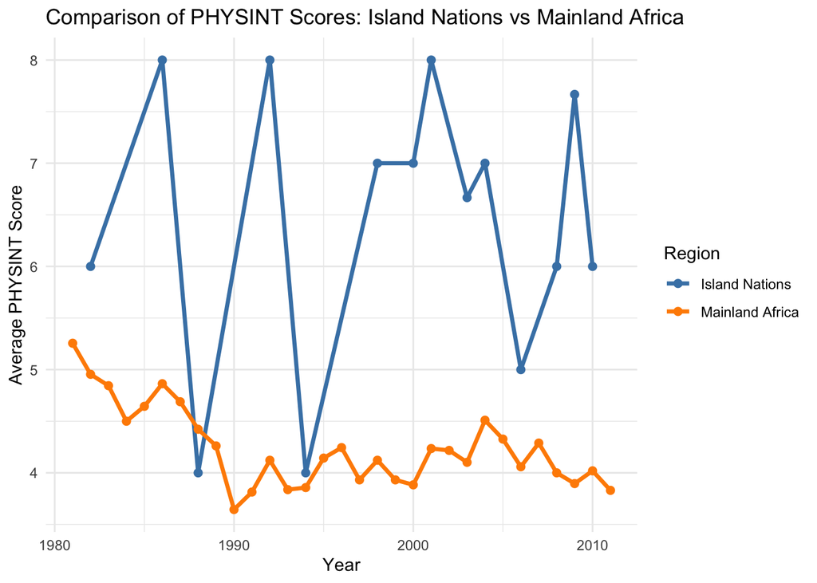

```r
ggplot(combined_df, aes(x = YEAR, y = PHYSINT, color = region)) +
  geom_line(stat = "summary", fun = mean, size = 1.2) +
  geom_point(stat = "summary", fun = mean, size = 2) +
  labs(
    title = "Comparison of PHYSINT Scores: Island Nations vs Mainland Africa",
    x = "Year",
    y = "Average PHYSINT Score",
    color = "Region"
  ) +
  theme_minimal() +
  scale_color_manual(values = c("Island Nations" = "steelblue", "Mainland Africa" = "darkorange"))
```

### Comparing the Differences in Women’s Political and Economic Rights Between Island Nations and Mainland by Decades

### WECON Comparison

```r
#Capturing the Average Scores from Data Set
mean_rights <- combined_df %>%
  group_by(DECADE, region) %>%
  summarize(
    mean_WECON = mean(WECON, na.rm = TRUE),
    mean_WOPOL = mean(WOPOL, na.rm = TRUE)
  ) %>%
  pivot_longer(
    cols = c(mean_WECON, mean_WOPOL),
    names_to = "Right_Type",
    values_to = "Mean_Score"
  )
```

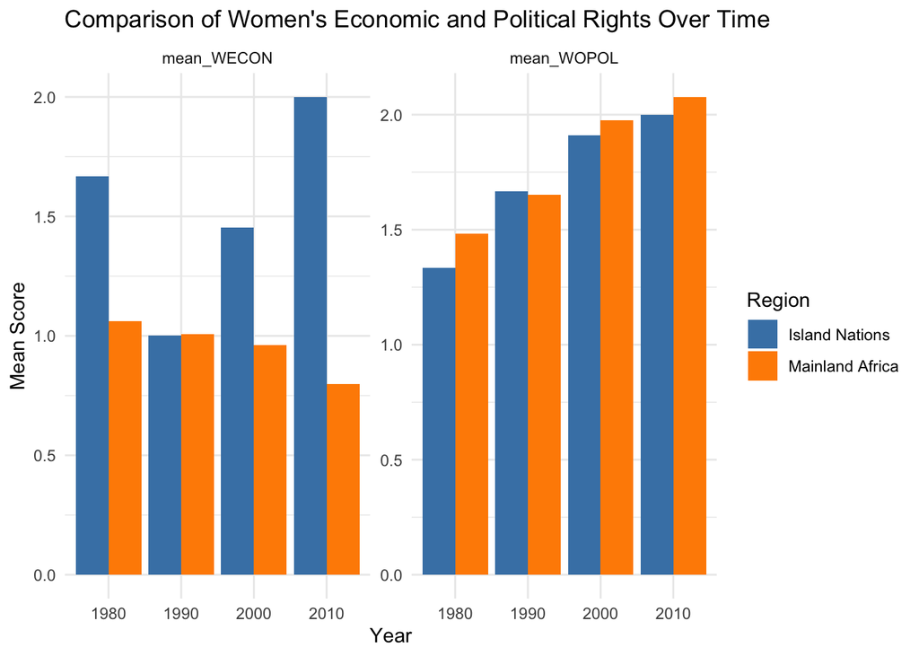

```r
#Comparisons
ggplot(mean_rights, aes(x = factor(DECADE), y = Mean_Score, fill = region)) +
  geom_bar(stat = "identity", position = "dodge") +
  facet_wrap(~ Right_Type, scales = "free_y") +
  labs(
    title = "Comparison of Women's Economic and Political Rights Over Time",
    x = "Year",
    y = "Mean Score",
    fill = "Region"
  ) +
  theme_minimal() +
  scale_fill_manual(values = c("Island Nations" = "steelblue", "Mainland Africa" = "darkorange"))
```

### Exploring Influential Factors Contributing to Women’s Economic Rights Between the Island Nations

We hypothesized that GDP, as a measure of a nation’s economic status, would be associated with women’s economic rights (WECON).

To explore this, we averaged the WECON scores over time for each island nation and plotted them against the corresponding average GDP values across the decades, arranged in ascending order of GDP. This visualization allowed us to examine whether higher economic status corresponded to greater women’s economic rights.

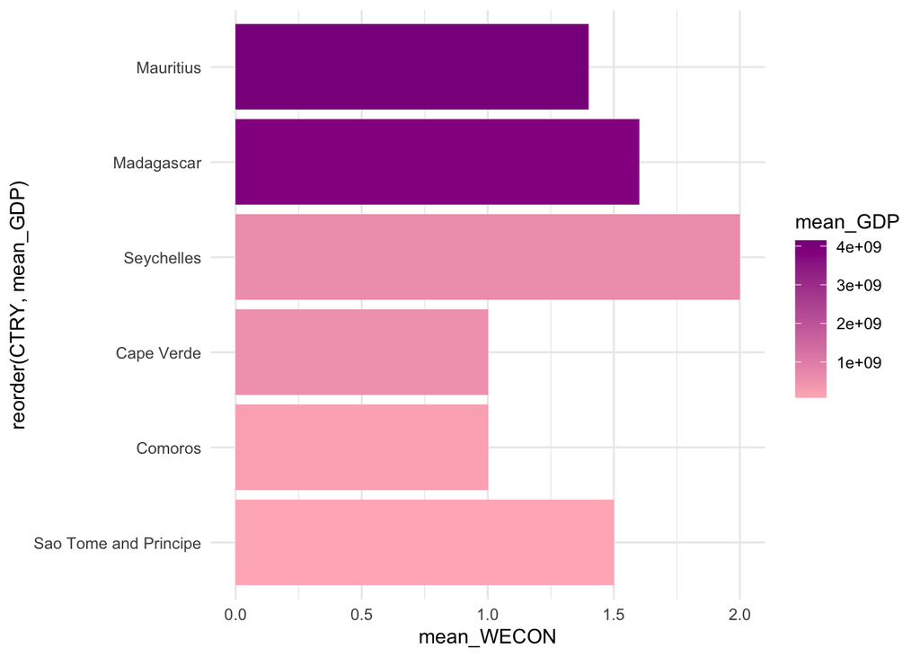

```r
summary_df <- islands_joined %>%
  group_by(CTRY) %>%
  summarize(
    mean_WECON = mean(WECON, na.rm = TRUE),
    mean_GDP = mean(GDP, na.rm = TRUE)
  )

ggplot(summary_df, aes(x = reorder(CTRY, mean_GDP), y = mean_WECON, fill = mean_GDP)) +
  geom_bar(stat = "identity") +
  scale_fill_gradient(low = "lightpink", high = "darkmagenta") +
  coord_flip() +
  theme_minimal()
```

From the visualization, there is no clear indication of any sort of trend/ correlation between the two variables of interests so we pivoted to a linear regression model.

```r
# Linear Regression Model
model1 <- lm(WECON ~ GDP + TPOP + URBPOP + AREA + TPOP*GDP, data = islands_joined)
summary(model1)
```

```
##
## Call:
## lm(formula = WECON ~ GDP + TPOP + URBPOP + AREA + TPOP * GDP,
##     data = islands_joined)
##
## Residuals:
##     Min      1Q  Median      3Q     Max
## -0.4983 -0.2642 -0.1249  0.4109  0.6004
##
## Coefficients:
##               Estimate Std. Error t value Pr(>|t|)
## (Intercept)  1.521e+00  1.999e-01   7.609 6.26e-06 ***
## GDP          2.585e-11  9.939e-11   0.260   0.7992
## TPOP        -3.536e-07  3.644e-07  -0.970   0.3511
## URBPOP      -5.731e-07  1.320e-06  -0.434   0.6718
## AREA         5.367e-07  3.340e-06   0.161   0.8750
## GDP:TPOP     1.127e-16  5.099e-17   2.211   0.0472 *
## ---
## Signif. codes:  0 '***' 0.001 '**' 0.01 '*' 0.05 '.' 0.1 ' ' 1
##
## Residual standard error: 0.4454 on 12 degrees of freedom
## Multiple R-squared:  0.4643, Adjusted R-squared:  0.2411
## F-statistic:  2.08 on 5 and 12 DF,  p-value: 0.1386
```

The multiple linear regression model examined the effects of GDP, total population (TPOP), urban population (URBPOP), land area (AREA), and the interaction between GDP and TPOP on WECON scores. The overall model was not statistically significant (F(5,12) = 2.08, p = 0.1386), and explained approximately only 24% of the variance in WECON scores after adjusting for the number of predictors (Adjusted R² = 0.2411).

Individually, most predictors, including GDP, TPOP, URBPOP, and AREA, were not statistically significant (p > 0.05). However, the interaction term GDP:TPOP was significant (p = 0.0472), suggesting that the combined effect of GDP and population may influence WECON scores even though the main effects alone are not significant.

Overall, while GDP alone does not appear to significantly predict WECON scores, its interaction with population may play a meaningful role, highlighting the importance of considering combined socio-economic factors.

### Exploring Influential Factors Contributing to Women’s Political Rights Between the Island Nations

We hypothesized that an island nation’s population size might influence women’s political rights (WOPOL). For example, in smaller populations, each individual’s opinion may carry more weight, potentially giving women greater influence in government.

To explore this, we averaged WOPOL scores over time for each island nation and plotted them against the corresponding average total population (TPOP) across the decades, arranged in ascending order of TPOP. This visualization allowed us to examine whether smaller populations were associated with higher women’s political rights.

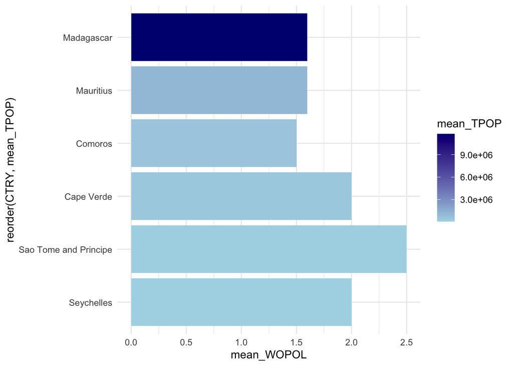

```r
summary_df2 <- islands_joined %>%
  group_by(CTRY) %>%
  summarize(
    mean_WOPOL = mean(WOPOL, na.rm = TRUE),
    mean_TPOP = mean(TPOP, na.rm = TRUE)
  )

ggplot(summary_df2, aes(x = reorder(CTRY, mean_TPOP), y = mean_WOPOL, fill = mean_TPOP)) +
  geom_bar(stat = "identity") +
  scale_fill_gradient(low = "lightblue", high = "navy") +
  coord_flip() +
  theme_minimal()
```

We cannot say for sure that there is a definitive correlation from this visual, but there does seem to be a trend where the smaller populations have generally higher women political rights.

To check if there is a correlation, we conducted a multiple linear regression to examine the effects of GDP, total population (TPOP), urban population (URBPOP), land area (AREA), and the interaction between TPOP and AREA on women’s political rights (WOPOL) in island nations.

```r
# Linear Regression Model 2
model2 <- lm(WOPOL ~ GDP + TPOP + URBPOP + AREA + TPOP*AREA, data = islands_joined)
summary(model2)
```

```
##
## Call:
## lm(formula = WOPOL ~ GDP + TPOP + URBPOP + AREA + TPOP * AREA,
##     data = islands_joined)
##
## Residuals:
##      Min       1Q   Median       3Q      Max
## -0.88689 -0.20184 -0.06699  0.17455  0.86125
##
## Coefficients:
##               Estimate Std. Error t value Pr(>|t|)
## (Intercept)  2.257e+00  2.538e-01   8.894 1.25e-06 ***
## GDP          9.635e-11  1.053e-10   0.915    0.378
## TPOP        -4.516e-07  9.331e-07  -0.484    0.637
## URBPOP      -9.344e-07  1.746e-06  -0.535    0.602
## AREA        -6.359e-06  3.801e-06  -1.673    0.120
## TPOP:AREA    1.441e-12  1.011e-12   1.425    0.180
## ---
## Signif. codes:  0 '***' 0.001 '**' 0.01 '*' 0.05 '.' 0.1 ' ' 1
##
## Residual standard error: 0.4891 on 12 degrees of freedom
## Multiple R-squared:  0.4383, Adjusted R-squared:  0.2043
## F-statistic: 1.873 on 5 and 12 DF,  p-value: 0.173
```

The overall model was not statistically significant (F(5,12) = 1.873, p = 0.173), explaining approximately only 20% of the variance in WOPOL scores after adjusting for the number of predictors (Adjusted R² = 0.2043).

Overall, these results indicate that, based on this dataset, there is no strong evidence that GDP, population size, urbanization, land area, or their interaction significantly predict women’s political rights in island nations.

### Exploring Influential Factors Contributing PHYSINT Between the Island Nations

Next, we wanted to explore if there were any correlations for variables within island nations to PHYSINT. We ran a multiple variable linear regression and after testing out multiple different variable interaction combinations, we were able to identify our most significant result with the following model:

```r
# Linear Regression Model 3
model3 <- lm(PHYSINT ~ GDP + TPOP + URBPOP + AREA + AREA*URBPOP, data = islands_joined)
summary(model3)
```

```
##
## Call:
## lm(formula = PHYSINT ~ GDP + TPOP + URBPOP + AREA + AREA * URBPOP,
##     data = islands_joined)
##
## Residuals:
##      Min       1Q   Median       3Q      Max
## -1.12503 -0.39143 -0.09048  0.69439  1.01198
##
## Coefficients:
##               Estimate Std. Error t value Pr(>|t|)
## (Intercept)  7.195e+00  4.002e-01  17.980 4.82e-10 ***
## GDP         -3.751e-10  1.987e-10  -1.888   0.0835 .
## TPOP        -1.454e-06  9.234e-07  -1.574   0.1414
## URBPOP       4.668e-06  2.548e-06   1.832   0.0918 .
## AREA         6.270e-06  7.148e-06   0.877   0.3976
## URBPOP:AREA  2.678e-12  3.996e-12   0.670   0.5155
## ---
## Signif. codes:  0 '***' 0.001 '**' 0.01 '*' 0.05 '.' 0.1 ' ' 1
##
## Residual standard error: 0.8826 on 12 degrees of freedom
## Multiple R-squared:  0.6694, Adjusted R-squared:  0.5317
## F-statistic:  4.86 on 5 and 12 DF,  p-value: 0.01163
```

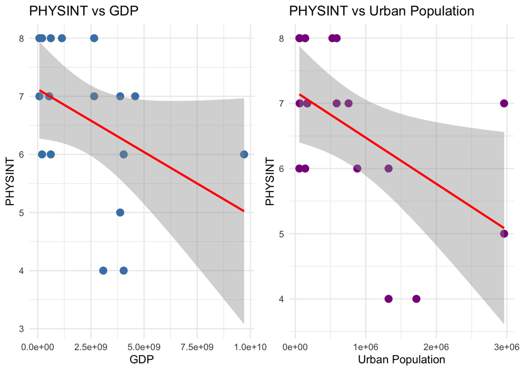

```r
# GDP
p1 <- ggplot(islands_joined, aes(x = GDP, y = PHYSINT)) +
  geom_point(size = 3, color = "steelblue") +
  geom_smooth(method = "lm", se = TRUE, color = "red", linewidth = 1) +
  labs(title = "PHYSINT vs GDP",
       x = "GDP",
       y = "PHYSINT") +
  theme_minimal()

# Urban Population
p2 <- ggplot(islands_joined, aes(x = URBPOP, y = PHYSINT)) +
  geom_point(size = 3, color = "darkmagenta") +
  geom_smooth(method = "lm", se = TRUE, color = "red", linewidth = 1) +
  labs(title = "PHYSINT vs Urban Population",
       x = "Urban Population",
       y = "PHYSINT") +
  theme_minimal()

grid.arrange(p1, p2, ncol = 2)
```

Plots of the two variable interactions that show slight significance.